# 9. ARIMA models.RMD

Russ Conte

10/30/2021

# 9. ARIMA models

ARIMA models provide another approach to time series forecasting. Exponential smoothing and ARIMA models are the two most widely used approaches to time series forecasting, and provide complementary approaches to the problem. While exponential smoothing models are based on a description of the trend and seasonality in the data, ARIMA models aim to describe the autocorrelations in the data.

Before we introduce ARIMA models, we must first discuss the concept of stationarity and the technique of differencing time series.

## 9.1 Stationarity and differencing

A stationary time series is one whose statistical properties do not depend on the time at which the series is observed.15 Thus, time series with trends, or with seasonality, are not stationary — the trend and seasonality will affect the value of the time series at different times. On the other hand, a white noise series is stationary — it does not matter when you observe it, it should look much the same at any point in time.

In general, a stationary time series will have no predictable patterns in the long-term. Time plots will show the series to be roughly horizontal (although some cyclic behaviour is possible), with constant variance.

## Differencing

Transformations such as logarithms can help to stabilise the variance of a time series. Differencing can help stabilise the mean of a time series by removing changes in the level of a time series, and therefore eliminating (or reducing) trend and seasonality.

As well as the time plot of the data, the ACF plot is also useful for identifying non-stationary time series. For a stationary time series, the ACF will drop to zero relatively quickly, while the ACF of non-stationary data decreases slowly. Also, for non-stationary data, the value of $r_1$ is often large and positive.

```r
library(tidyverse)
library(fpp3)
google_stock <- gafa_stock %>%
  filter(Symbol == "GOOG", year(Date) >= 2015) %>%
  mutate(day = row_number()) %>%
  update_tsibble(index = day, regular = TRUE)
# Filter the year of interest
google_2015 <- google_stock %>% filter(year(Date) == 2015)

google_2015 %>%
  mutate(diff_close = difference(Close)) %>%
  features(diff_close, ljung_box, lag = 10)
```

```
## # A tibble: 1 × 3
##   Symbol lb_stat lb_pvalue
##   <chr>    <dbl>     <dbl>
## 1 GOOG      7.91     0.637
```

Let’s look at an autocorrelation of the Close price of Goolge 2015 stock:

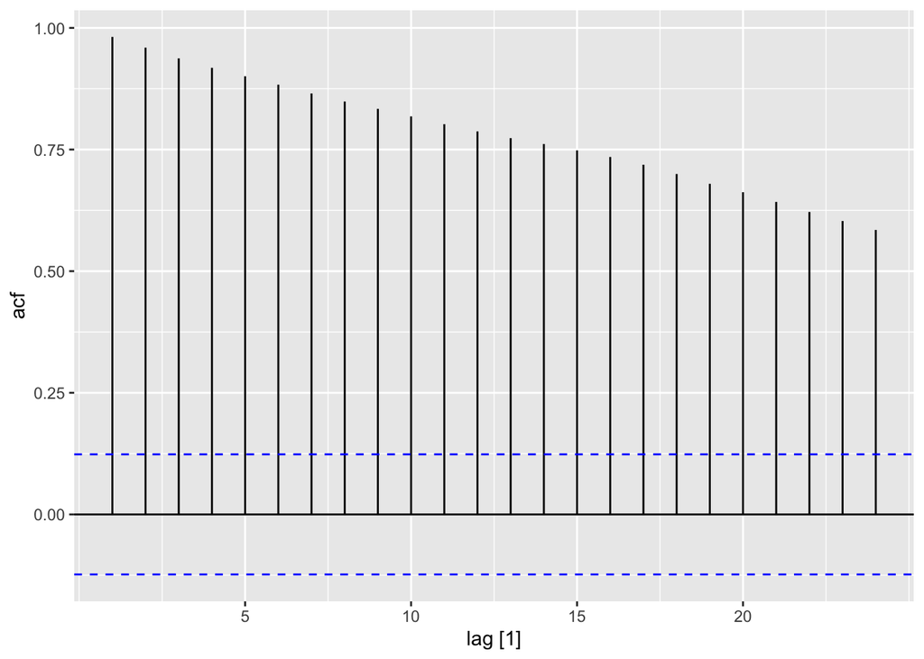

```r
google_2015 %>%
  ACF(Close) %>%
  autoplot()
```

Let’s look at a graph of the lag of the Close price of Google2015

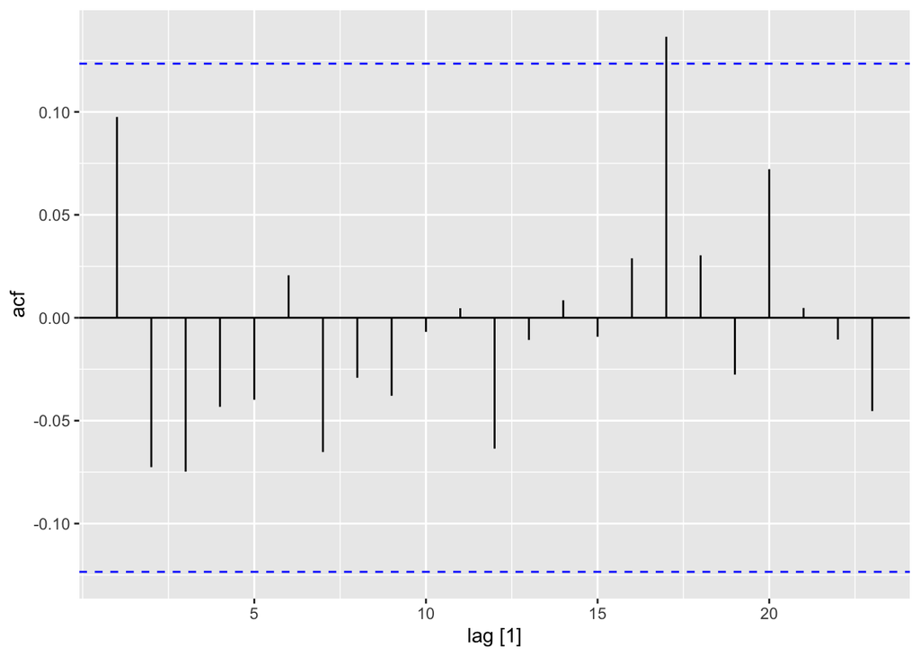

```r
google_2015 %>%
  mutate(diff_close = difference(Close)) %>%
  ACF(diff_close) %>%
  autoplot()
```

The ACF of the differenced Google stock price looks just like that of a white noise series. Only one autocorrelation is outside of the 95% limits, and the Ljung-Box $Q^*$statistic has a p-value of 0.637 (for $h =$10). This suggests that the daily change in the Google stock price is essentially a random amount which is uncorrelated with that of previous days.

## Random walk model

The differenced series is the *change* between consecutive observations in the original series, and can be written as:

$y^{'}_t = y_t - y_{t-1}$

The differenced series will have only $T - 1$ values, since it is not possible to calculate a difference, $y^{'}$ for the first observation.

When the differenced series is white noise, the model for the original series can be written as:

$y_t - y_{t-1} = \epsilon_t$

where $\epsilon_t$ denotes white noise. Rearranging this leads to the “random walk” model,

$y_t = y_{t-1} + \epsilon_t$

Random walk models are widely used for non-stationary data, particularly financial and economic data. Random walks typically have:

• Long periiods of apprent trneds up or down • Sudden and unpredictable changes in direction

The forecasts from a random walk model are equal to the last observation, as future movements are unpredictable, and are equally likely to be up or down. Thus, the random walk model underpins naïve forecasts, first introduced in Section 5.2.

A closely related model allows the differences to hvaswe a non-zero mean. Then:

$y_t - y_{t-1} = c + \epsilon_t$ or $y_t = c + y_{t-1} + \epsilon_t$

The value of $c$ is the average of the changes between consecutive observations. If $c$ is positive, then the average change is an increase in the value of $y_t$. Thus, $y_t$ will tend to drift upwards. However, if $c$ is negative, $y_t$ will tend to drift downwards.

This is the model behind the drift method, also discussed in Section 5.2.

## Second-order differencing

Occasionally the differenced data will not appear to be stationary and it may be necessaryto difference the data a second time to obtain a stationary series:

$y_t^{''} = y_t^{'} - y_{t-1}^{'}$

## Seasonal differencing

A seasonal difference is the difference between an observation and the previous observation from the same season. So:

$y_t^{'} = y_t - y_{t-m},$

where $m$= the number of seasons.These are also called “lag-m differences,” as we subtract the observation after a lag of $m$ periods.

If the seasonaly differenced data appear to ber white noise, then an appropriate model for the original data is:

$y_t = y_{t-m} + \epsilon_t$

Forecasts from this model are equal to the last observation from the relevant season. That is, this model gives seasonal näive forecasts, introduced in Section 5.2

To distinguish seasonal differences from ordinary differences, we sometimes refer to ordinary differences as “first differences,” meaning differences at lag 1.

Sometimes it is necessary to take both a seasonal difference and a first difference to obtain stationary data. Figure 9.4 plots Australian corticosteroid drug sales ($AUD) (top panel). Here, the data are first transformed using logarithms (second panel), then seasonal differences are calculated (third panel). The data still seem somewhat non-stationary, and so a further lot of first differences are computed (bottom panel).

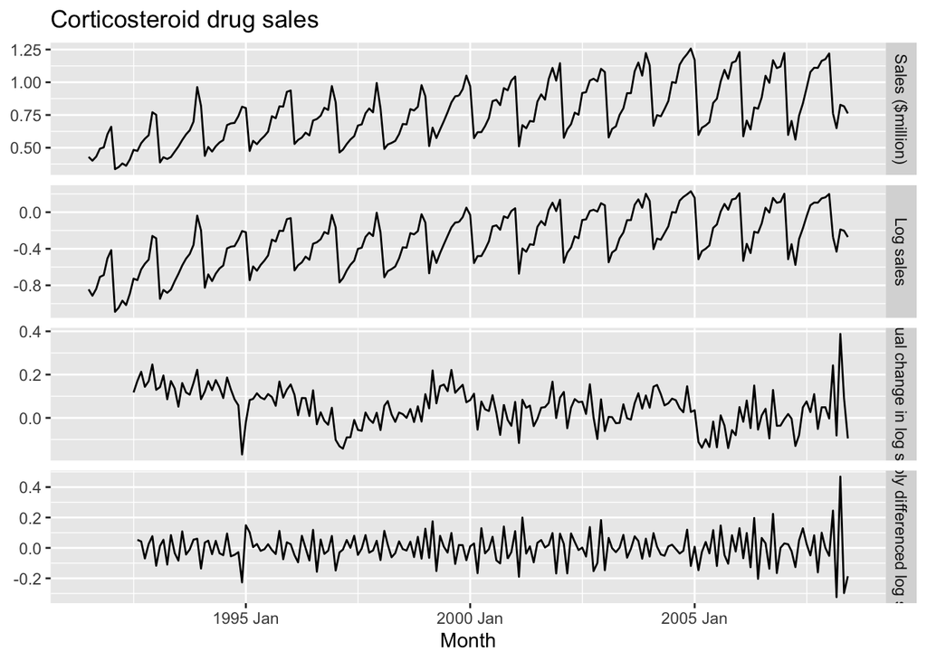

```r
PBS %>%
  filter(ATC2 == "H02") %>%
  summarise(Cost = sum(Cost)/1e6) %>%
  transmute(
    `Sales ($million)` = Cost,
    `Log sales` = log(Cost),
    `Annual change in log sales` = difference(log(Cost), 12),
    `Doubly differenced log sales` = difference(difference(log(Cost), 12), 1)
    ) %>%
  pivot_longer(-Month, names_to = "Type", values_to = "Sales") %>%
  mutate(
    Type = factor(Type, levels = c(
      "Sales ($million)",
      "Log sales",
      "Annual change in log sales",
      "Doubly differenced log sales"))
  ) %>%
  ggplot(aes(x = Month, y = Sales)) +
  geom_line() +
  facet_grid(vars(Type), scales = "free_y") +
  labs(title = "Corticosteroid drug sales", y = NULL)
```

If $y_t^{'} =y_t - y_{t-m}$ denotes a seasonally differenced series, then the twice-differenced series is:

$y_t^{''} = y_t^{'} - y_{t-1}^{'}$ $= (y_t - y_{t-m}) - (t_{t-1} - y_{t - m - 1})$ $= y_t - t_{t-1} - y_{t-m} + y_{t-m-1}$

When both seasonal and first differences are applied, it makes no difference which is done first—the result will be the same. However, if the data have a strong seasonal pattern, we recommend that seasonal differencing be done first, because the resulting series will sometimes be stationary and there will be no need for a further first difference. If first differencing is done first, there will still be seasonality present.

Beware that applying more differences than required will induce false dynamics or autocorrelations that do not really exist in the time series. Therefore, do as few differences as necessary to obtain a stationary series.

It is important that if differencing is used, the differences are interpretable. First differences are the change between one observation and the next. Seasonal differences are the change between one year to the next. Other lags are unlikely to make much interpretable sense and should be avoided.

## Unit root tests

One way to determine more objectively whether differencing is required is to use a *unit root test*. These are statistical hypothesis tests of stationarity that are designed for determining whether differencing is required.

Let’s apply the *Kwiatkowski-Phillips-Schmidt-Snit (KPSS)* test to the Goolge 2015 stock price data:

```r
google_2015 %>%
  features(Close, unitroot_kpss)
```

```
## # A tibble: 1 × 3
##   Symbol kpss_stat kpss_pvalue
##   <chr>      <dbl>       <dbl>
## 1 GOOG        3.56        0.01
```

The p-value is reported as 0.01 if it is less than 0.01, and as 0.1 if it is greater than 0.1. In this case, the test statistic (3.56) is bigger than the 1% critical value, so the p-value is less than 0.01, indicating that the null hypothesis is rejected. That is, the data are not stationary. We can difference the data, and apply the test again.

```r
google_2015 %>%
  mutate(diff_close = difference(Close)) %>%
  features(diff_close, unitroot_kpss)
```

```
## # A tibble: 1 × 3
##   Symbol kpss_stat kpss_pvalue
##   <chr>      <dbl>       <dbl>
## 1 GOOG      0.0989         0.1
```

his time, the test statistic is tiny, and well within the range we would expect for stationary data, so the p-value is greater than 0.1. We can conclude that the differenced data appear stationary.

This process of using a sequence of KPSS tests to determine the appropriate number of first differences is carried out using the unitroot_ndiffs() feature.

```r
google_2015 %>%
  features(Close, unitroot_ndiffs)
```

```
## # A tibble: 1 × 2
##   Symbol ndiffs
##   <chr>   <int>
## 1 GOOG        1
```

As we saw from the KPSS tests above, one difference is required to make the `google_2015` data stationary.

A similar feature for determining whether seasonal differencing is required is `unitroot_nsdiffs()`, which uses the measure of seasonal strength introduced in Section 4.3 to determine the appropriate number of seasonal differences required. No seasonal differences are suggested if $F_s \lt 0.64$, otherwise one seasonal difference is suggested.

We can apply the `unitroot_nsdiffs()` to the monthly total Australian retail turnover.

```r
aus_total_retail <- aus_retail %>%
  summarise(Turnover = sum(Turnover))

aus_total_retail %>%
  mutate(log_turnover = log(Turnover)) %>%
  features(log_turnover, unitroot_nsdiffs)
```

```
## # A tibble: 1 × 1
##   nsdiffs
##     <int>
## 1       1
```

```r
aus_total_retail %>%
  mutate(log_turnover = difference(log(Turnover), 12)) %>%
  features(log_turnover, unitroot_nsdiffs)
```

```
## # A tibble: 1 × 1
##   nsdiffs
##     <int>
## 1       0
```

## 9.2 Backshift notation

The backward shift operator $B$ is a useful notationla device when working with time series lags:

$B_{y_{t}} = y_{t-1}$

In other words, $B$, operating on $y_t$, has the effect of shifting the data back one period. Two applications of $B$ to $y_t$ shifts the data back two periods:

$B(B_{y_{t}}) = B^2y_t = y_{t-2}$

For monthly data, if we wish to consider “the same month last year,” the notation is $B^{12}y_t = y_{t -12}$

The backward shift operator is convenient for describing the process of *differencing*. The first difference can be written as:

$y_t^{'} = y_t - y_{t-1} = y_t - By_t = (1 - B)y_t$

So the first difference can be represented by $(1 - B)$. Similary, if second-order differences have to be computed, then:

$y_t^{''} = y_t - 2y_{t-1} + y_{t-2} = (1 - 2B + B^2)y_t = (1 - B)^2y_t$

In general, the dth-order difference can be written as:

$(1 - B)^d y_t$

Backshift notation is particularly useful when combining differences, as the operator can be treated using ordinary algebraic rules. In particular, terms involving $B$ can be multiplied together.

In a multiple regression model, introduced in Chapter 7, we forecast the variable of interest using a linear combination of predictors. In an autoregression model, we forecast the variable of interest using a linear combination of *past values of the variable*. The term autoregression indicates that it is a regression of the variable against itself.

Thus, an autoregressive model of order $p$ can be written as:

$y_t = c + \phi_1y_{t-1} + \phi_2y_{t-2} + ... + \phi_py_{t-p} + \epsilon_t$

where $\epsilon_t$ is white noise. This is like a multiple regression but with lagged values of $y_t$ as predictors. We refer to this as an **AR($p$)** model, an autoregressive model of order $p$.

We normally restrict autoregressive models to stationary data, in which case some constraints on the values of the parameters are required:

• For an AR(1) model: $-1 \lt \phi_1 \lt 1$  
• For an AR(2) model: $-1 \lt \phi_2 \lt1, \phi_1 +\phi_2 \lt 1, \phi_2 - \phi_1 <1$

When $p \geq3$, the restrictions are much more complicated. The `fable` package takes care of these restrictions when estimating a model.

## 9.4 The moving average models

Rather than using past values of the forecast variable in a regression, a moving average model uses past forecast errors in a regression-like model,

$y_t = c + \epsilon_t + \theta_1 \epsilon_{t-1} +\theta_2 \epsilon_{t-2} +\theta_q \epsilon_{t-q}$

where $\epsilon_t$ is white noise. We refer to this as an **MA(q) model**, a moving average model of order $q$. Of course, we do not *observe* the value of $\epsilon_t$, so it is not really a regression in the usual sense.

Notice that each value of $y_t$ can be thought of as a weighted moving average of the past few forecast errors (although the coefficients will not normally sum to one). However, moving average models should not be confused with the moving average smoothing we discussed in Chapter 3. A moving average model is used for forecasting future values, while moving average smoothing is used for estimating the trend-cycle of past values.

It is possible to write any stationary AR($p$) model as an MA($\infty$) model. For example, using repeated substitution, we can demonstrate this for an AR(1) model:

$y_t = \phi y_{t-1} + \epsilon_t$  
$\phi_1(\phi_1 y_{t-2} + \epsilon_{t-1}) + \epsilon_t$  
$\phi_1^2 y_{t-2} + \phi \epsilon_{t-1} + \epsilon_t$  
$\phi_1^3 y_{t-3} + \phi^2 \epsilon_{t-2} + \phi_1\epsilon_{t-1} + \epsilon_t$  
etc.

Provided $-1 \lt \phi_1 \lt 1$ the value of $\phi_1^k$ will get smaller as $k$ gets larger. So eventually we obtain:

$y_t = \epsilon_t + \phi_1 \epsilon_{t-1} + \phi_1^2 \epsilon_{t-2} + \phi_1^3 \epsilon_{t-3} + ...,$

am MA($\infty$) process.

The reverse result holds if we impose some constraints on the MA parameters. Then the MA model is called invertible. That is, we can write any invertible MA($q$) process as an AR($\infty$) process. Invertible models are not simply introduced to enable us to convert from MA models to AR models. They also have some desirable mathematical properties.

For example, consider the MA(1) process, $y_t = \epsilon_t + \theta_1 \epsilon_{t-1}$. In its AR($\infty$) representation, the most recent error can be written as a linear function of current and past observations:

$\epsilon_t = \sum_{j=0}^\infty (-\theta_1)^j y_{t-j}$

When $\left| \theta_1 \right|\gt 1$, he weights increase as lags increase, so the more distant the observations the greater their influence on the current error. When $\left| \theta_1 \right| = 1$ the weights are constant in size, and the distant observations have the same influence as the recent observations. As neither of these situations make much sense, we require $\left| \theta_1 \right| \lt 1$ so the most recent observations have higher weight than observations from the more distant past. Thus, the process is invertible when $\left| \theta_1 \right| \lt 1$.

The invertaibility constraints for other models are similar to the stationarity constraints.

•For an MA(1) model: $-1 \lt \theta_1 \lt 1$  
•For an MA(2) model: $-1 \lt \theta_2 \lt 1, \theta_2 + \theta_1 \gt -1, \theta_1 - \theta_2 \lt 1$

More complicated conditions hold for $q \ge 3$. Again, the `fable` package will take care of these constraints when estimating the models.

# 9.5 Non-seasonal ARIMA models

If we combine differencing with autoregression and a moving average model, we obtain a non-seasonal ARIMA model. ARIMA is an acronym for AutoRegressive Integrated Moving Average (in this context, “integration” is the reverse of differencing). The full model can be written as

$y_t^{'} = c + \phi_1y_{t-1}^{'}+...+\phi_py_{t-p}^{'} + \theta_1\epsilon_{t-1} + ... +\theta_q\epsilon_{t-q} + \epsilon_t$

where $y'_{t}$ is the differenced series (it may have been differenced more than once). The “predictors” on the right hand side include both lagged values of $y_t$ and lagged errors. We cal this an **ARIMA(p, d, q) model** where

| $p$ = the order of the autoregressive part |
| --- |
| $d$ = degree of the first differencing involved |
| $p$ = order of the moving average part |

The same stationarity and invertibility conditions that are used for autoregressive and moving average models also apply to an ARIMA model.

Many of the models we have already discussed are special cases of the ARIMA model, as shown in Table 9.1.

Table 9.1: Special cases of ARIMA models.

| White noise | ARIMA(0,0,0) with no constant |
| --- | --- |
| Random walk | ARIMA(0,1,0) with no constant |
| Random walk with drift | ARIMA(0,1,0) with a constant |
| Autoregression | ARIMA($p$,0,0) |
| Moving average | ARIMA(0,0,$q$) |

Once we start combining components in this way to form more complicated models, it is much easier to work with the backshift notation. For example, Equation (9.1) can be written in backshift notation as

$(1 - \phi_1B - \cdots - \phi_pB^p) \quad (1-B)^d y_t \quad= \quad c +(1 + \theta_1B + \cdots + \theta_qB^q) \epsilon_t$

$\qquad \qquad \uparrow \qquad \qquad \qquad \quad \uparrow \qquad \qquad \qquad \quad \qquad \uparrow$

$\qquad \quad AR(p) \qquad \qquad \text{d-differences} \qquad \qquad \qquad MA(q)$

Selecting appropriate values for $p, d, \text{and } q$can be difficult. However, the `ARIMA()` function from the `fable` package will do it for you automatically. In Section 9.7, we will learn how this function works, along with some methods for choosing these values yourself.

## Egyptian exports example

Figure 9.7 shows Egyptian exports as a percentage of GDP from 1960 to 2017.

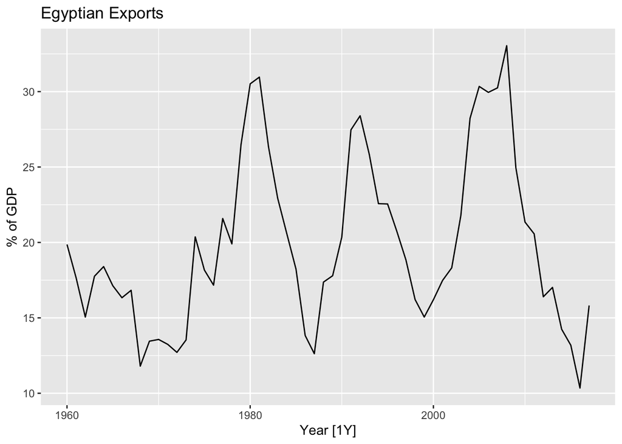

```r
global_economy %>%
  filter(Code == "EGY") %>%
  autoplot(Exports) +
  labs(y = "% of GDP", title= "Egyptian Exports")
```

The following R code selects a non-seasonal ARIMA model automatically:

```r
fit <- global_economy %>%
  filter(Code == "EGY") %>%
  model(ARIMA(Exports))
report(fit)
```

```
## Series: Exports
## Model: ARIMA(2,0,1) w/ mean
##
## Coefficients:
##          ar1      ar2      ma1  constant
##       1.6764  -0.8034  -0.6896    2.5623
## s.e.  0.1111   0.0928   0.1492    0.1161
##
## sigma^2 estimated as 8.046:  log likelihood=-141.57
## AIC=293.13   AICc=294.29   BIC=303.43
```

This is an ARIMA(2,0,1) model, where:

$y_t = 2.5623 + 1.6764y_{t-1} - 0.8034 y_{t-2} - 0.6896 \epsilon_{t-1} + \epsilon_t$

where $\epsilon_t$ is white noise with a standard deviation of 2.837 = $\sqrt{8.046}$. Forecasts from the model are shown in Figure 9.8. Notice how they have picked up the cycles evident in the Egyptian economy over the last few decades.

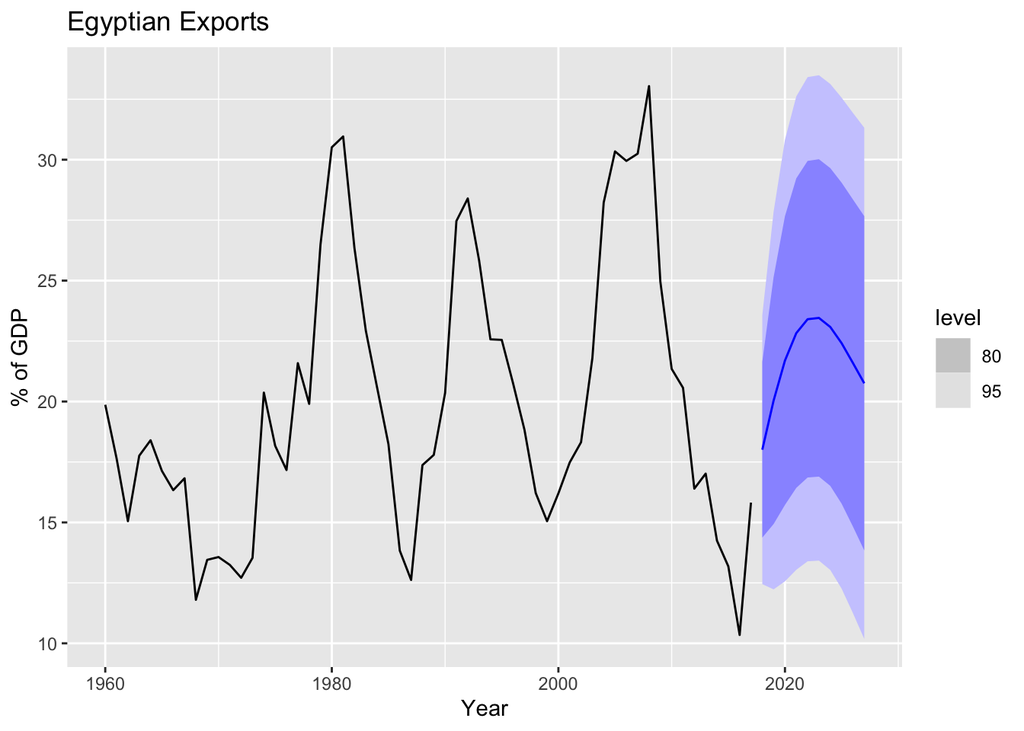

```r
fit %>% forecast(h = 10) %>%
  autoplot(global_economy)+
  labs(y = "% of GDP", title = "Egyptian Exports")
```

## Understanding ARIMA models

The `ARIMA()` function is useful, but anything automated can be a little dangerous, and is worth understanding something of the behavior of the models even when you rely on an automatic procedure to choose the model for you.

The constant $c$ has an important effect on the long-term forecasts obtained from these results

• If $c = 0 \text{ and } d = 0$, the long-term forecasts will go to zero.  
• If $c = 0 \text{ and } d = 1$, the long-term forecasts will go to a non-zero constant.  
• If $c = 0 \text{ and } d = 2$, the long term foreasts will follow a straight line.  
• If $c \ne 0 \text{ and } d = 0$, the long-term forecasts will go to the mean of the data.  
• If $c \ne 0 \text{ and } d = 1$, the long term forecasts will follow a straight line.  
• If $c \ne 0 \text{ and } d = 2$, the long-term forecasts will follow a quadratic trend. This is not recommended, and `fable` will not permit it.)

The value of $d$ also has an effect on the prediction intervals — the higher the value of $d$, the more rapidly the prediction intervals increase in size. For $d = 0$, the long-term forecast standard deviation will go to the standard deviation of the historical data, so the prediction intervals will all be essentially the same.

This behaviour is seen in Figure 9.8 where $d = 0 $and $c \ne 0$ . In this figure, the prediction intervals are almost the same width for the last few forecast horizons, and the final point forecasts are close to the mean of the data.

The value of $p$ is important if the data show cycles. To obrain cyclic forecasts, it is necessary to have $p \ge 2$, along with some additoionla conditions on the parameters. For an AR(2) mode, cyclic bhaviour occurs is $\phi_1^2 + 4 \phi_2 \lt 0 (as is the case for the Egyptian Exports model).$ In that case, the average period of the cycles is:

## $\frac{2\pi}{\text{arc cos}(-\phi_1(1 - \phi_2)/(4phi_2))}$

## ACF and PACF plots

It is usually not possible to tell, simply from a time plot, what values of $p$ and $q$ are appropriate for the data. However, it is sometimes possible to use the ACF plot, and the closely related PACF plot, to determine appropriate values for $p$ and $q$.

Recall that an ACF plot shows the autocorrelations which measure the relationship between $y_t$ and $y_{t-k}$ for different values of $k$. Now if $y_t$ and $y_{t-1}$ are correlated, then $y_{t-1}$ and $y_{t-2}$ must also be correlated. However, then $y_t$ and $t_{t-2}$ might be correlated, simply because they are both connected to $t_{t-1}$, rathern than because of any new information contained in $y_{t-2}$ that could be used in forecasting $y_t$

To overcome this problem, we can use **partial autocorrelations**. These measure the relationship between $y_t$ and $y_{t-k}$ after removing the effects of lags 1, 2, 3, …, k-1. So the first partial autocorrelation is identical to the first autocorrelation, because there is nothing between them to remove. Each partial autocorrelation can be estimated as the last coefficient in an autoregressive model. Specifically, $\alpha_k$, the $k$th partial autocorrelation coefficient, is equal to the estimate of $\phi_k$ in an AR(k) model. In practice, there are more efficeint algorithms for computing $\alpha_k$ than fitting all of these autoregressions, but they give the same results.

Figures 9.9 and 9.10 shows the ACF and PACF plots for the Egyptian exports data shown in Figure 9.7. The partial autocorrelations have the same critical values of $\pm 1.96 / \sqrt{T}$ as for ordinary autocorrelations, and these are typically shown on the plot as in Figure 9.10.

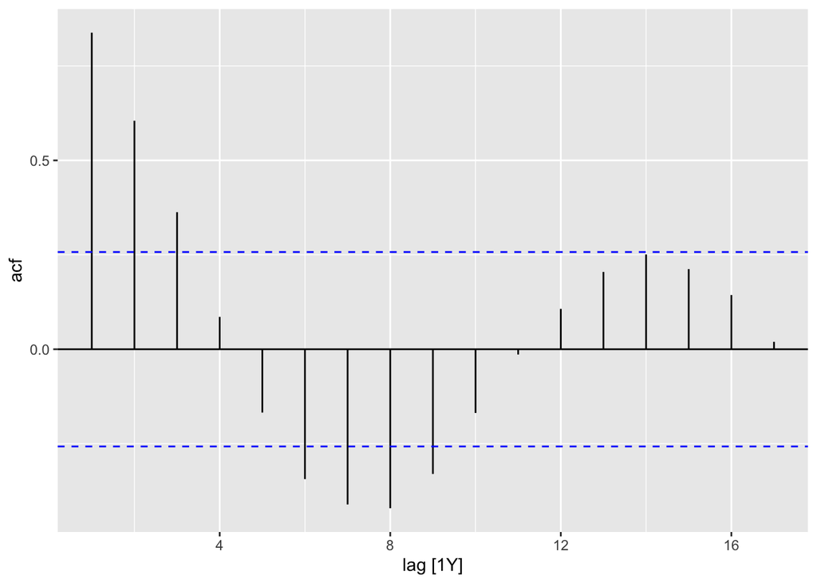

```r
global_economy %>%
  filter(Code == "EGY") %>%
  ACF(Exports) %>%
  autoplot()
```

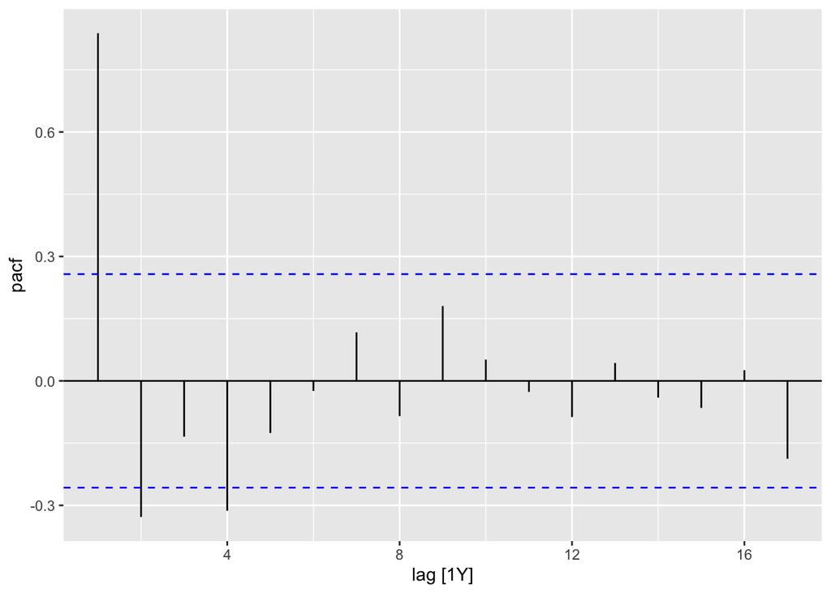

```r
global_economy %>%
  filter(Code == "EGY") %>%
  PACF(Exports) %>%
  autoplot()
```

A convenient way to produce a time plot, ACF plot and PACF plot in one command is to use the `ggtsdisplay()` function with `plot_type = "partial`.

If the data are from an ARIMA($p, d, 0$) or ARIMA($0, d, q$) model, then the ACF and PACF plots can be helpful in determining the value of $p$ or $q$. If $p$ and $q$ are both positive, then the plots do not help in finding suitable values of $p$ and $q$.

The data may follow an ARIMA($p, d, 0$) model if the ACF and PACF plots of the differenced data show the following patterns:

• the ACF is exponentially decaying or sinusoidal; • there is a significant spike at lag $p$ in the PACF, but none beyond lag $p$. . The data may follow an ARIMA(0, $d, q$) model if the ACF and PACF plots of the differenced data show the following patterns:

• the PACF is exponentially decaying or sinusoidal; • there is a significant spike at lag $q$in the ACF, but none beyond lag $q$.

In Figure 9.9, we see that there is a decaying sinusoidal pattern in the ACF, and in Figure 9.10 the PACF shows the last significant spike at lag 4. This is what you would expect from an ARIMA(4,0,0) model.

```r
fit2 <- global_economy %>%
  filter(Code == "EGY") %>%
  model(ARIMA(Exports ~ pdq(4,0,0)))
report(fit2)
```

```
## Series: Exports
## Model: ARIMA(4,0,0) w/ mean
##
## Coefficients:
##          ar1      ar2     ar3      ar4  constant
##       0.9861  -0.1715  0.1807  -0.3283    6.6922
## s.e.  0.1247   0.1865  0.1865   0.1273    0.3562
##
## sigma^2 estimated as 7.885:  log likelihood=-140.53
## AIC=293.05   AICc=294.7   BIC=305.41
```

This model is only slightly worse than the ARIMA(2,0,1) model identified by `ARIMA()` (with an AICc value of 294.70 compared to 294.29).

## 9.6 Estimation and order selection

### Maximum likelihood estimation

Once the model order has been identified (i.e. the values of $p, d, \test{ and }q$), we need to estimate the paramaters $c, phi_1,,...,phi_p, \theta_1,...\theta_q$. When `fable` estimates the ARIMA model, it uses *maximum liklihoos estimation* (MLE). This technique finds the values of the parameters which maximise the probability of obtaining the data that we have observed. For ARIMA models, MLE is similar to the *least squares* estimates that would be obtained by minimising

#### $\sum_{t = 1}^T \epsilon_t^2$

(For the regression models considered in Chapter 7, MLE gives exactly the same parameter estimates as least squares estimation.) Note that ARIMA models are much more complicated to estimate than regression models, and different software will give slightly different answers as they use different methods of estimation, and different optimisation algorithms.

In practice, the `fable` package will report the value of the *log likelihood* of the data; that is, the logarithm of the probability of the observed data coming from the estimated model. For given values of $p, d \test{ and } q$, `ARIMA()` will try to maximise the log likelihood when finding paramter estimates.

### Information Criteria

Akaike’s Information Criterion (AIC), which was useful in selecting predictors for regression (see Section 7.5), is also useful for determining the order of an ARIMA model. It can be written as

#### $AIC = -2log(L) + 2(p + q + k + 1)$

where $L$ is the likelihood of the data, $k = 1$ if $c \ne 0$ and $k = 0$ if $c = 0$. Note that the last term in parentheses is the number of parameters in the model (including $\sigma^2$), the variance of the residuals.

For ARIMA models, the corrected AIC can be written as:

#### $AIC_c = AIC + \frac{2(p+q+k+1)(p+q+k+2)}{T-p-q-k-2}$

and the Bayesian Information Criterion can be written as:

#### $BIC = AIC + [log(T) - 2](p+q+k+1)$

Good models are obtained by minimising the AIC, AICc or BIC. Our preference is to use the AICc.

It is important to note that these information criteria tend not to be good guides to selecting the appropriate order of differencing ($d$) of a model, but only for selecting the values of $p$ and $q$. This is because the differencing changes the data on which the likelihood is computed, making the AIC values between models with different orders of differencing not comparable. So we need to use some other approach to choose $d$, and then we can use the AICc to select $p$ and $q$.

Completion through section 9.6

#9.7 ARIMA modelling in `fable`

### How does `ARIMA()` work?

The `ARIMA()` model in the `fable` package uses a variation of the Hyndma = Khandakar algorighm (Hyndman & Khandakar, 2008), whic combines unit root tests, minimisation of AICc and MLE to obtain an ARIMA model. The arguemnts to `ARIMA()` provide for many variations on the algorithm What is described here is the defaul behavior.

**Hundmak-Khandakar Algorithm for automatic ARIMA modelling|**  
1. The number of differences $0 \le d \le 2$ is determined using repeated KPSS tests  
2. The values of $p$ and $q$ are then chosen by mimising the AICc after differencing the data $s$ times. Rather than considering every possible combination of $p$ and $q$, the algorithm uses a stepwise search to traverse the model space.  
$\qquad$ a. Four initial models are fitted:  
$\qquad \qquad$ ARIMA(0, d, 0)  
$\qquad \qquad$ ARIMA(2, d, 2)  
$\qquad \qquad$ ARIMA(1, d, 0)  
$\qquad \qquad$ ARIMA(0, d, 1)  
A constant is included unless:  
d = 2. If  
$d \le 1$, an additional model is also fitted:  
$\qquad \qquad$ ARIMA(0, d, 0) without a constant  
b. The best model (with the smallest AICc value) fitted in step (a) is set to be the “current model”  
c. Variations on the current model are considered:  
vary $p$ and/or $q$ from the current model by $\pm 1$; include/exclude $c$ from the current model. The best model considered so far (either the current model or one of these variations) becomes the new current model.  
d. Repeat Step 2(c) until no lower AICc can be found

## Modelling procedure

When fitting an ARIMA model to a set of (non-seasonal) time series data, the following procedure provides a useful general approach.

1. Plot the data and identify any unusual observations.
2. If necessary, transform the data (using a Box-Cox transformation) to stabilise the variance.
3. If the data are non-stationary, take first differences of the data until the data are stationary.
4. Examine the ACF/PACF: Is an ARIMA($p, d, 0$) or an ARIMA($0, d,q$) model appropriate?
5. Try your chosen model(s), and use the AICc to search for a better model.
6. Check the residuals from your chosen model by plotting the ACF of the residuals, and doing a portmanteau test of the residuals. If they do not look like white noise, try a modified model.
7. Once the residuals look like white noise, calculate forecasts.

The Hyndman-Khandakar algorithm only takes care of steps 3–5. So even if you use it, you will still need to take care of the other steps yourself.